# Environmental indicator analysis-Tilefish

##### Cold pool analysis

Excerpt from New York Bight Fish, Fisheries, and Sand Features: Data Review Volume 1: Literature Synthesis and Gap Analysis:

Natural events are documented for Scup (Morse 1978; Smith and Norcross 1968), Bluefish (Slater et al. 2007), and Northern Puffer (Wicklund 1970) in the MAB and NYB as a result of upwelling of cold bottom water, and for Golden Tilefish on the OCS from eastward flow of the Cold Pool (Fisher et al. 2014). Such events are difficult to detect and quantify because they are episodic, because they could happen in winter when there are few observers, or because they leave dead animals on the bottom instead of floating (Fisher et al.2014) so that they are only detected incidentally by trawler (e.g., Woodhead (1964)).

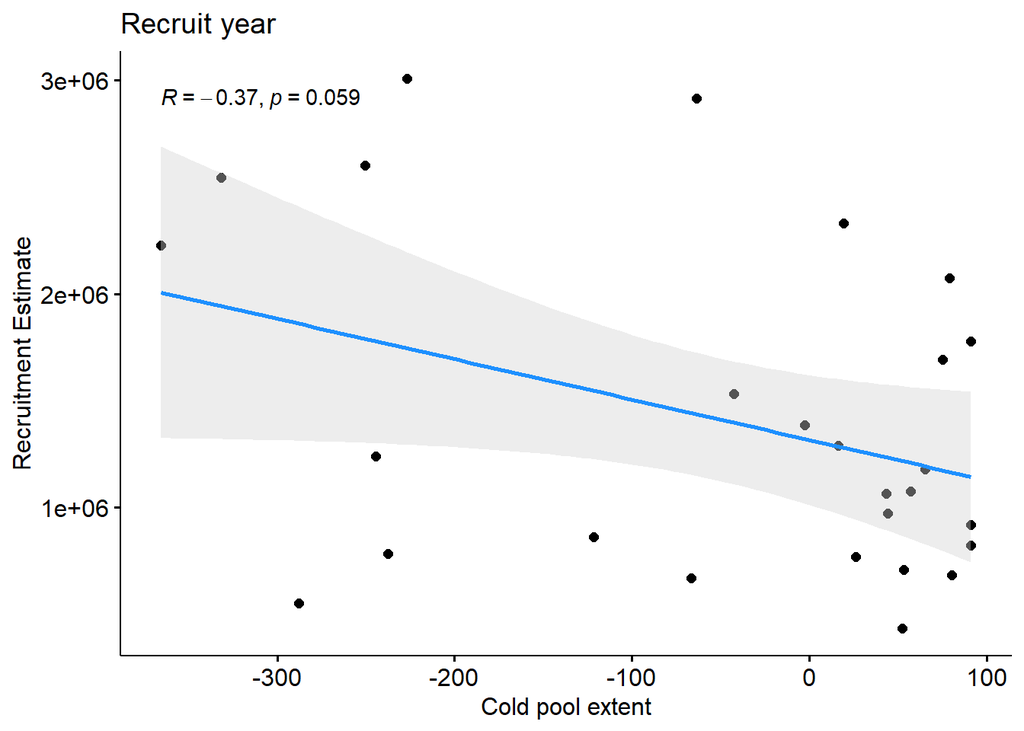

```r
library(ecodata)
# Pull cold pool data
cp.ex <- ecodata::cold_pool
# Selecting just the extent
cp <- cp.ex %>% filter(Time %in% c(1994:2020),
              Var == 'extent_index') %>%
  mutate(ext = Value,
         ext_lag1 = lag(ext,1),
         year = as.numeric(Time))
## NOTE: I added more lags (up to 7), but they only got worse - may make more
## sense to do more lags with cpue data with older fish


# Join with recruit estimate
cp.rec <- dplyr::full_join(recruit, cp, by = join_by(year)) %>%
  dplyr::select(year, recruit_est, ext, ext_lag1) %>%
  filter(year %in% c(1994:2020))

cp.rec %>%
  ggscatter(x = 'ext', y = 'recruit_est',
            add = "reg.line", conf.int = TRUE,
            cor.coef = TRUE, cor.coeff.args = list(method="pearson"),
            add.params=list(color="dodgerblue", fill="lightgray"),
            xlab = "Cold pool extent", ylab = "Recruitment Estimate",
            title="Recruit year")
```

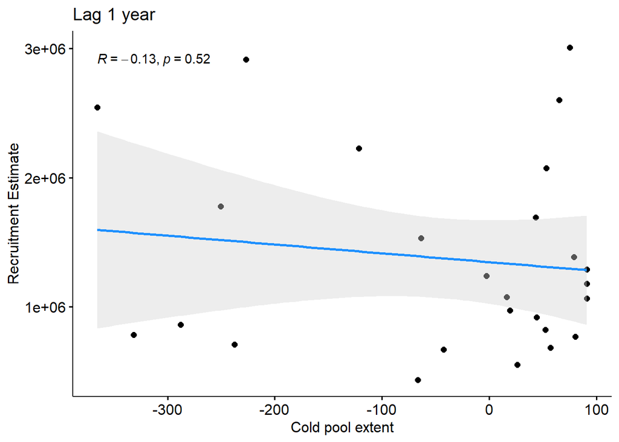

```r
cp.rec %>%
  ggscatter(x = 'ext_lag1', y = 'recruit_est',
            add = "reg.line", conf.int = TRUE,
            cor.coef = TRUE, cor.coeff.args = list(method="pearson"),
            add.params=list(color="dodgerblue", fill="lightgray"),
            xlab = "Cold pool extent", ylab = "Recruitment Estimate",
            title="Lag 1 year")
```

#### Currents

Cross-shelf processes may influence the retention or displacement of tilefish during early life history stages. These are explored below.

##### Shelf water volume

Shelf water volume: A measure of the volume of water bounded inshore of the shelf-slope front. In this analysis, shelf water is defined as all water having salinity <34 psu. The position of the shelf-slope front varies inter-annually with the higher shelf water values indicating the front being pushed further towards the shelf break.

high shv: front pushed towards sbf low shv: front pushed inshore (more slope water on shelf)

Hypothesis: Higher recruitment success correlated with years of higher shelf water volume in spring/summer. These months months may be particularly important as that is when spawning is occurring and the position of the sbf may influence the position of larvae (away from spawning grounds).

Additional variables in this dataset are shelf water temperature and salinity which may also be indicative of habitat conditions.

```r
# Shelf water volume
shlfvol <- read.csv(here::here('data/shelf_water_volume/ShelfWaterVolume_BSB_update.csv'))

# wrangling date info, converting doy to date and month
yrs <- as.vector(nrow(shlfvol))
shlfvol$Year <- as.character(shlfvol$Year)
for (i in 1:nrow(shlfvol)){
  yrs[i] <- strsplit(shlfvol$Year, ".", fixed = TRUE)[[i]][1]
}
shlfvol$year <- yrs

shlfvol <- shlfvol %>% mutate(date_= as.Date(Year.Day-1,
                                             origin=paste0(year, "-01-01")),
                              month= strftime(date_, "%m"),
                              day=strftime(date_,"%d"),
                              year = as.integer(year),
                              month = as.numeric(month))


# Create shw vol by month w/lag
df.lag = shlfvol %>%
  group_by(year,month) %>%
  summarise(mean_t = mean(ShW.T),
            mean_s = mean(ShW.S),
            mean_v = mean(ShW.Vol)) %>%
  mutate(mean_t_lag2 = lag(mean_t,2),
         mean_t_lag3 = lag(mean_t,3),
         mean_t_lag6 = lag(mean_t,6),
         mean_s_lag2 = lag(mean_s,2),
         mean_s_lag3 = lag(mean_s,3),
         mean_s_lag6 = lag(mean_s,6),
         mean_v_lag2 = lag(mean_v,2),
         mean_v_lag3 = lag(mean_v,3),
         mean_v_lag6 = lag(mean_v,6))
# Join in-situ bottom temps w/assessment recruitment estimate
df.join.shlf = dplyr::full_join(recruit, df.lag, by = join_by(year)) %>%
  dplyr::select(year, month, recruit_est, mean_t, mean_s, mean_v,
                mean_t_lag2, mean_s_lag2, mean_v_lag2,
                mean_t_lag3, mean_s_lag3, mean_v_lag3) %>%
  tidyr::drop_na()
```

##### Shelf Water Volume Analysis

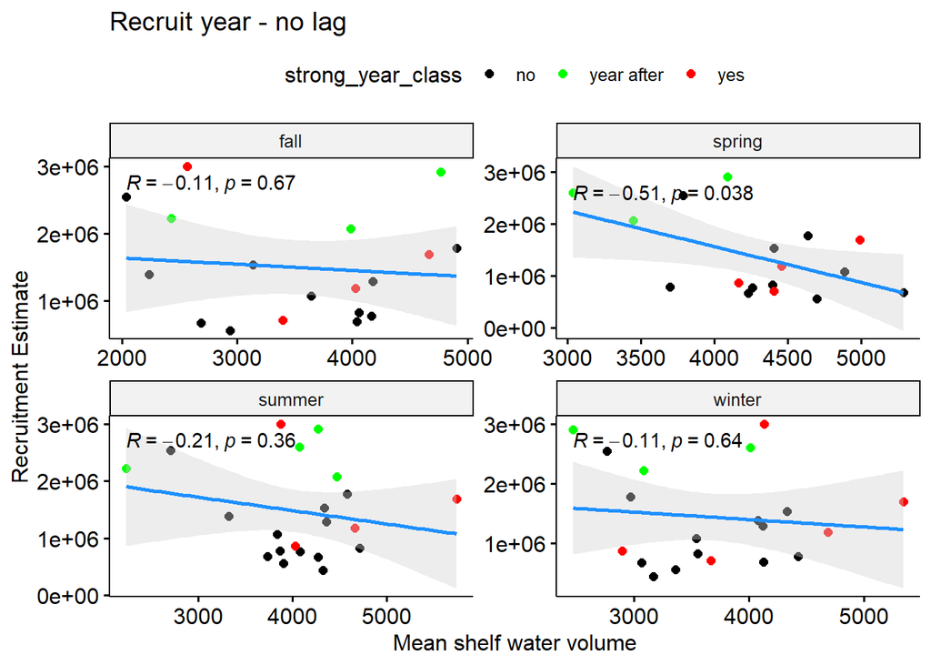

```r
df.join.shlf = dplyr::full_join(recruit, df.lag, by = join_by(year)) %>%
  dplyr::select(year, month, recruit_est, mean_v) %>%
  tidyr::drop_na() #removing lags to visualize all months

df.join.shlf = df.join.shlf %>%
  filter(year %in% c(1998:2020)) %>%
  mutate(v_lag3 = lag(mean_v,3),
         v_lag6 = lag(mean_v,6),
         v_lag9 = lag(mean_v,9),
         v_lag12 = lag(mean_v,12)) #creating seasonal and one year lags

df = df.join.shlf %>%
  mutate(season = case_when(month %in% c(1,2,3) ~ 'winter',
                            month %in% c(4,5,6) ~ 'spring',
                            month %in% c(7,8,9) ~ 'summer',
                            month %in% c(10,11,12) ~ 'fall'),
         strong_year_class = case_when(year %in% c(1998,1999,2005,2013,2017) ~ 'yes',
                                  year %in% c(2000,2006,2014,2018) ~ 'year after',
                                  year %in% c(2001:2004,2007:2012,2015:2016,2019:2020) ~ 'no'))


# Plot without lag
df %>% group_by(year, season, strong_year_class) %>%
  summarize(v = mean(mean_v),
            r = mean(recruit_est)) %>%
  ggscatter(x = "v", y = "r",
            add = "reg.line", conf.int = TRUE,
            color = "strong_year_class", palette = c("black", "green", "red"),
            cor.coef = TRUE, cor.coeff.args = list(method="pearson"),
            add.params=list(color="dodgerblue", fill="lightgray"),
            xlab = "Mean shelf water volume", ylab = "Recruitment Estimate",
            title="Recruit year - no lag")+
  facet_wrap(~season, scales = 'free')
```

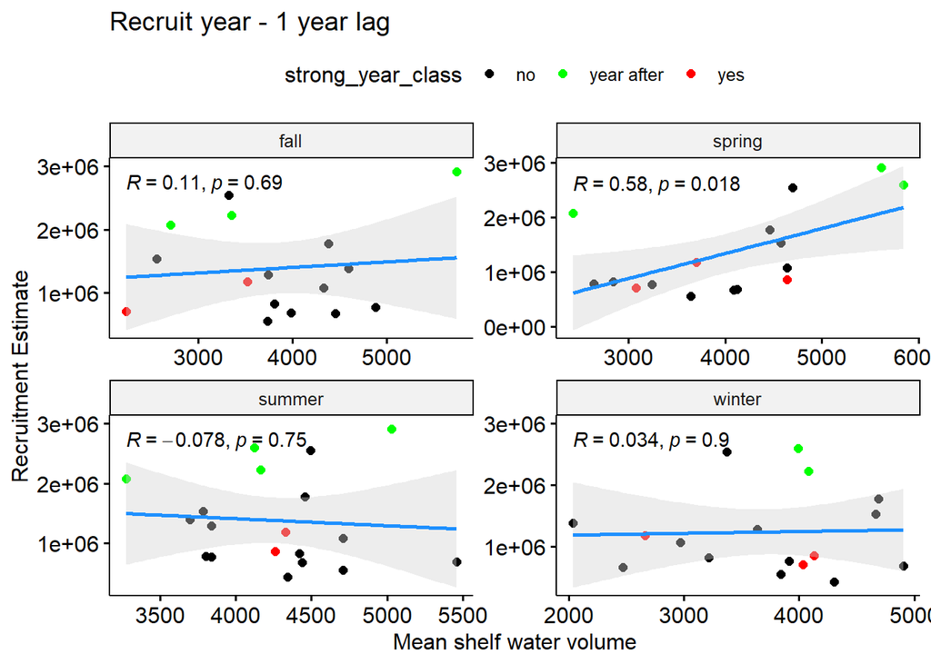

```r
# Plot with lag
df %>% group_by(year, season, strong_year_class) %>%
  summarize(v = mean(v_lag12),
            r = mean(recruit_est)) %>%
  ggscatter(x = "v", y = "r",
            add = "reg.line", conf.int = TRUE,
            color = "strong_year_class", palette = c("black", "green", "red"),
            cor.coef = TRUE, cor.coeff.args = list(method="pearson"),
            add.params=list(color="dodgerblue", fill="lightgray"),
            xlab = "Mean shelf water volume", ylab = "Recruitment Estimate",
            title="Recruit year - 1 year lag")+
  facet_wrap(~season, scales = 'free')
```

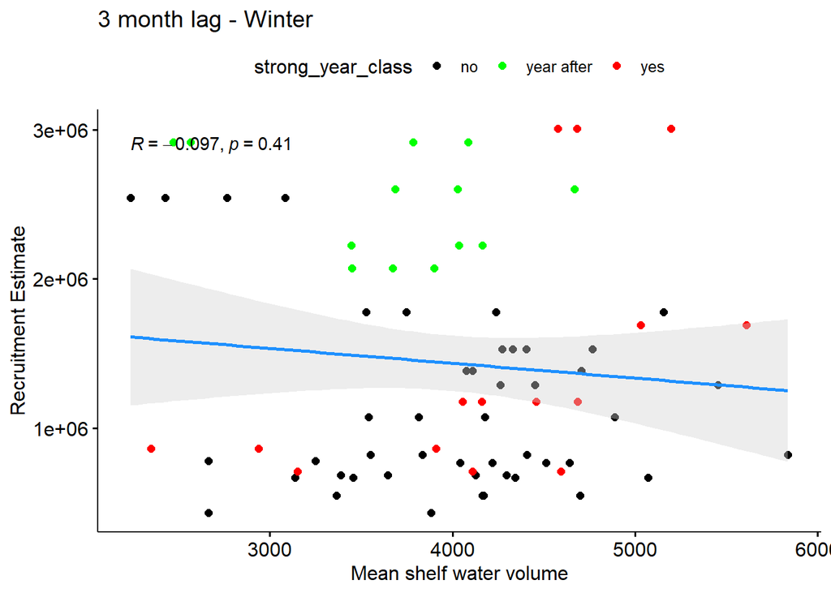

```r
## 3 month lag (winter)

df %>% group_by(year, season, strong_year_class) %>%
  summarize(v = mean(v_lag3),
            r = mean(recruit_est)) %>%
  ggscatter(x = "v", y = "r",
            add = "reg.line", conf.int = TRUE,
            color = "strong_year_class", palette = c("black", "green", "red"),
            cor.coef = TRUE, cor.coeff.args = list(method="pearson"),
            add.params=list(color="dodgerblue", fill="lightgray"),
            xlab = "Mean shelf water volume", ylab = "Recruitment Estimate",
            title="3 month lag - Winter")
```

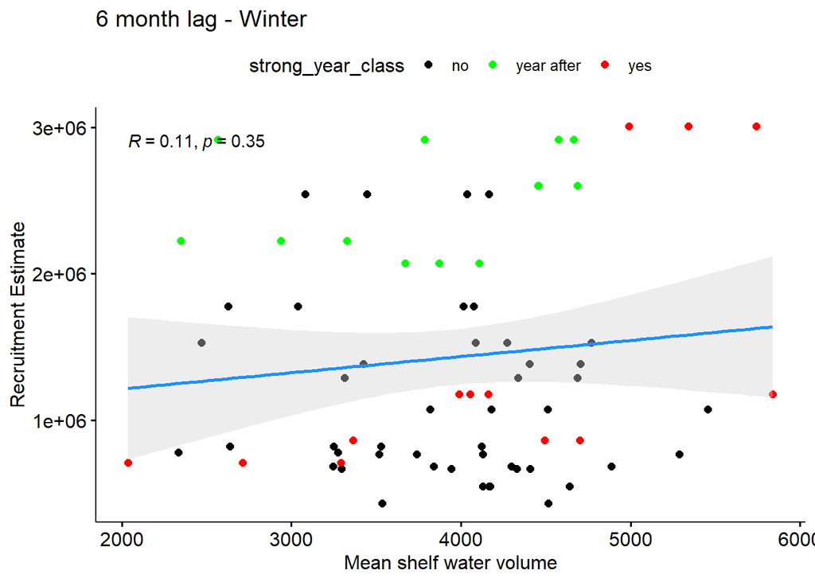

```r
## 6 month lag (winter)

df %>% group_by(year, season, strong_year_class) %>%
  summarize(v = mean(v_lag6),
            r = mean(recruit_est)) %>%
  ggscatter(x = "v", y = "r",
            add = "reg.line", conf.int = TRUE,
            color = "strong_year_class", palette = c("black", "green", "red"),
            cor.coef = TRUE, cor.coeff.args = list(method="pearson"),
            add.params=list(color="dodgerblue", fill="lightgray"),
            xlab = "Mean shelf water volume", ylab = "Recruitment Estimate",
            title="6 month lag - Winter")
```

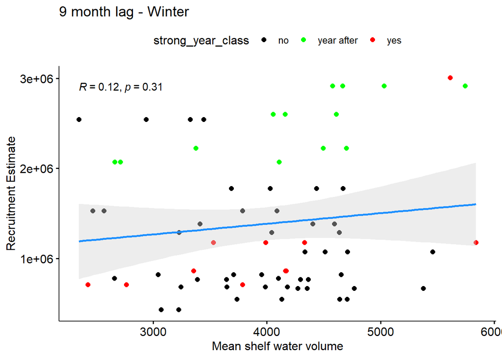

```r
## 9 month lag (winter)

df %>% group_by(year, season, strong_year_class) %>%
  summarize(v = mean(v_lag9),
            r = mean(recruit_est)) %>%
  ggscatter(x = "v", y = "r",
            add = "reg.line", conf.int = TRUE,
            color = "strong_year_class", palette = c("black", "green", "red"),
            cor.coef = TRUE, cor.coeff.args = list(method="pearson"),
            add.params=list(color="dodgerblue", fill="lightgray"),
            xlab = "Mean shelf water volume", ylab = "Recruitment Estimate",
            title="9 month lag - Winter")
```

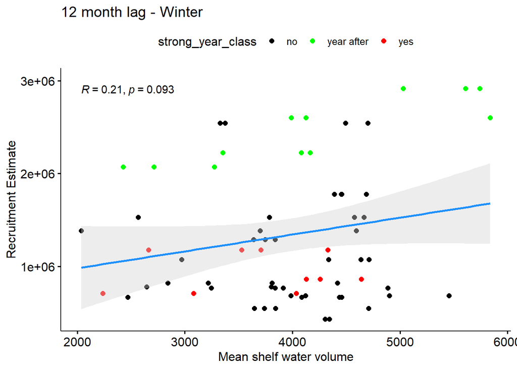

```r
## 12 month lag (winter)

df %>% group_by(year, season, strong_year_class) %>%
  summarize(v = mean(v_lag12),
            r = mean(recruit_est)) %>%
  ggscatter(x = "v", y = "r",
            add = "reg.line", conf.int = TRUE,
            color = "strong_year_class", palette = c("black", "green", "red"),
            cor.coef = TRUE, cor.coeff.args = list(method="pearson"),
            add.params=list(color="dodgerblue", fill="lightgray"),
            xlab = "Mean shelf water volume", ylab = "Recruitment Estimate",
            title="12 month lag - Winter")
```

##### Gulf-stream index

Gulf stream index was calculated based on method presented by Pérez-Hernández and Joyce (2014). The gulf stream index (GSI) is a measure of the degrees latitude above the average Gulf Stream position based on ocean temperature at 200m (15 C) depth between 55W to 75W.

Positive values indicate a the mean position of the GS is more Northernly, whereas negative values indicate a more Southernly position.

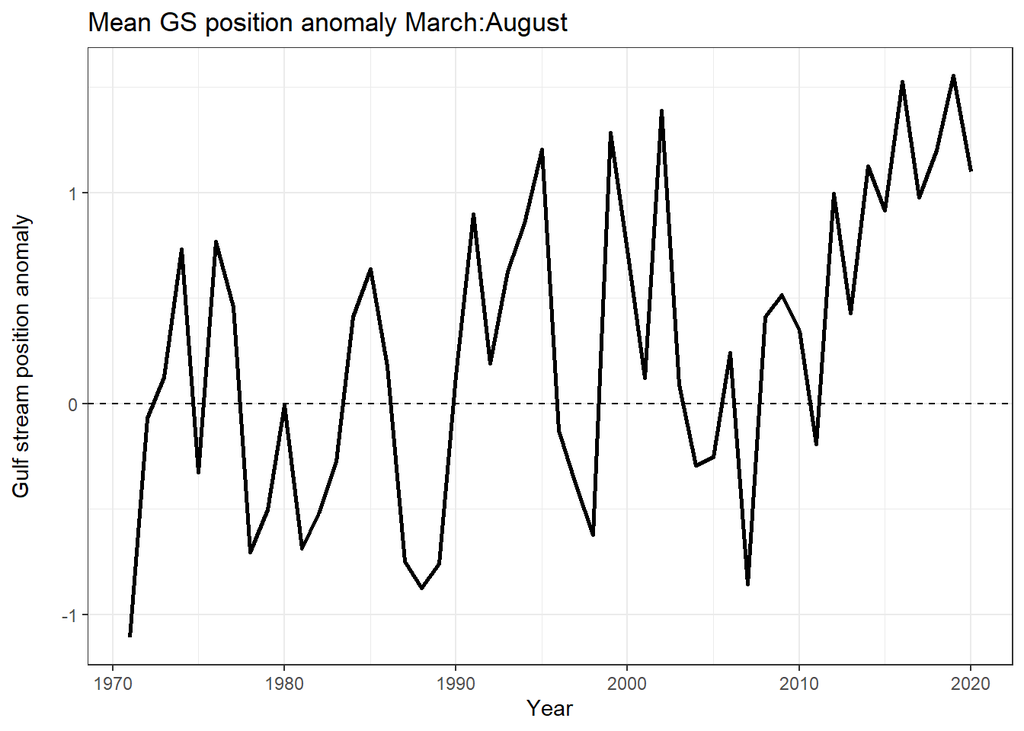

```r
gsi.m <- read.csv(here::here('data/gulf_stream_index/mm_gsi_1954_2022_chen.csv'))


## --- This joins recruit estimate data to GSI data and
## --- calculates some summary stats(mean, sd, min, max)
df <- dplyr::full_join(recruit, gsi.m %>%
                   group_by(year) %>%
                   filter(month %in% c(3:8)) %>%
                   summarise(m.gsi = mean(GSI),
                             sd.gsi = sd(GSI),
                             max.gsi = max(GSI),
                             min.gsi = min(GSI)),
                 by = join_by(year)) %>%
  mutate(pos = ifelse(m.gsi > 0, 'Northerly', 'Southerly'),
         n.pos = ifelse(m.gsi > 0, 1, 0))
df <- df[-c(51:69),] # this removes rows w/years that don't match
# (could/should do this before hand in more standardized way - will do later)

# Plot the time series (mean GSI for the months of interest)
# -- Note: here I am looking just at March through August assuming these
# months are the most important to recently spawned individuals
ggplot(data = df,
       aes(x = year, y = m.gsi)) +
  geom_line(lwd = 1) +
  geom_hline(yintercept = 0, lty = 2) +
  labs(title = 'Mean GS position anomaly March:August',
       x = 'Year',
       y = "Gulf stream position anomaly\n") +
theme_bw()
```

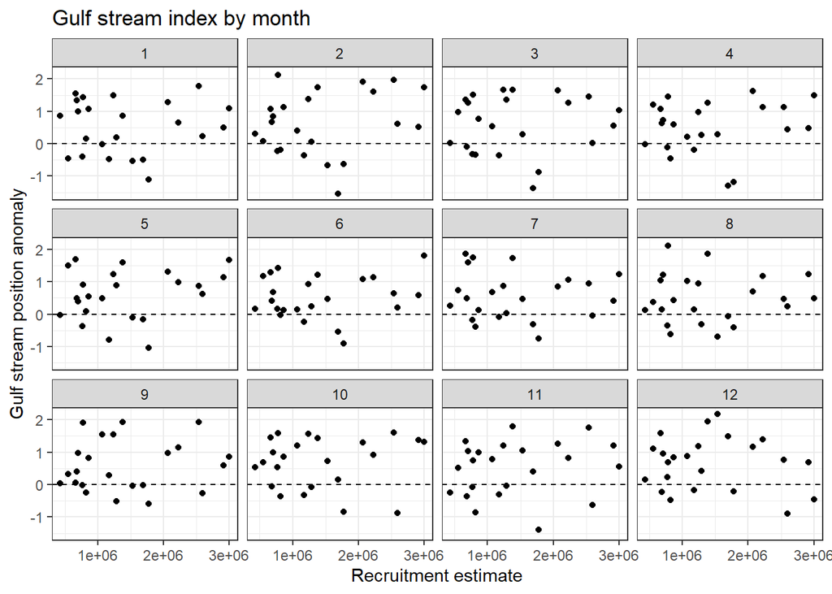

```r
# Looking across all months
dplyr::full_join(recruit, gsi.m, by = join_by(year)) %>%
  dplyr::select(year, month, recruit_est, GSI) %>%
  #filter(month %in% c(3:9)) %>%
  filter(year>1997) %>%
  tidyr::drop_na() %>%
ggplot2::ggplot(.,aes(x=recruit_est, y=GSI)) +
  geom_point(color = 'black') +
  facet_wrap(~month)+
  xlab('Recruitment estimate') +
  ylab('Gulf stream position anomaly') +
  labs(title = 'Gulf stream index by month') +
  geom_hline(yintercept = 0, lty = 2) +
  theme_bw()
```

##### Gulf Stream Index Analysis

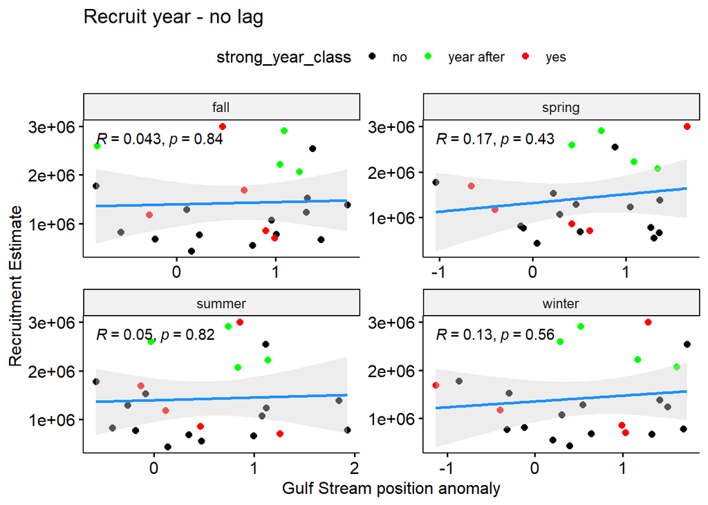

```r
df.gsi = dplyr::full_join(recruit, gsi.m, by = join_by(year)) %>%
  dplyr::select(year, month, recruit_est, GSI) %>%
  mutate(gsi_3 = lag(GSI,3),
         gsi_6 = lag(GSI,6),
         gsi_9 = lag(GSI,9),
        gsi_12 = lag(GSI,12)) %>%
  filter(year>1997) %>%
  tidyr::drop_na() #GSI by month and with year lag

df = df.gsi %>%
  mutate(season = case_when(month %in% c(1,2,3) ~ 'winter',
                            month %in% c(4,5,6) ~ 'spring',
                            month %in% c(7,8,9) ~ 'summer',
                            month %in% c(10,11,12) ~ 'fall'),
         strong_year_class = case_when(year %in% c(1998,1999,2005,2013,2017) ~ 'yes',
                                  year %in% c(2000,2006,2014,2018) ~ 'year after',
                                  year %in% c(2001:2004,2007:2012,2015:2016,2019:2020) ~ 'no'))

# Plot without lag
df %>% group_by(year, season, strong_year_class) %>%
  summarize(gsi = mean(GSI),
            r = mean(recruit_est)) %>%
  ggscatter(x = "gsi", y = "r",
            add = "reg.line", conf.int = TRUE,
            color = "strong_year_class", palette = c("black", "green", "red"),
            cor.coef = TRUE, cor.coeff.args = list(method="pearson"),
            add.params=list(color="dodgerblue", fill="lightgray"),
            xlab = "Gulf Stream position anomaly", ylab = "Recruitment Estimate",
            title="Recruit year - no lag")+
  facet_wrap(~season, scales = 'free')
```

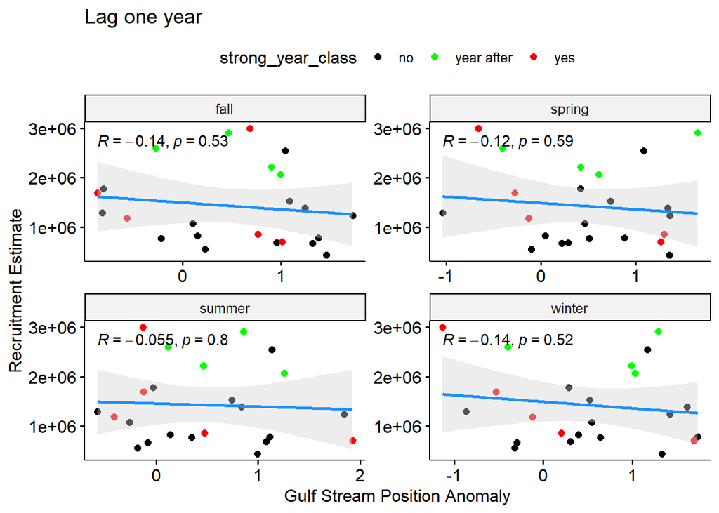

```r
# Plot with 1 year lag
df %>% group_by(year, season, strong_year_class) %>%
  summarize(gsi = mean(gsi_12),
            r = mean(recruit_est)) %>%
  ggscatter(x = "gsi", y = "r",
            add = "reg.line", conf.int = TRUE,
            color = "strong_year_class", palette = c("black", "green", "red"),
            cor.coef = TRUE, cor.coeff.args = list(method="pearson"),
            add.params=list(color="dodgerblue", fill="lightgray"),
            xlab = "Gulf Stream Position Anomaly", ylab = "Recruitment Estimate",
            title="Lag one year")+
  facet_wrap(~season, scales = 'free')
```

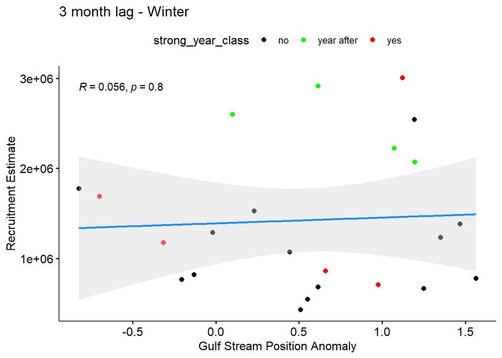

```r
## Seasonal lags

# 3 month lag - Winter
df %>% group_by(year, strong_year_class) %>%
  summarize(gsi = mean(gsi_3),
            r = mean(recruit_est)) %>%
  ggscatter(x = "gsi", y = "r",
            add = "reg.line", conf.int = TRUE,
            color = "strong_year_class", palette = c("black", "green", "red"),
            cor.coef = TRUE, cor.coeff.args = list(method="pearson"),
            add.params=list(color="dodgerblue", fill="lightgray"),
            xlab = "Gulf Stream Position Anomaly", ylab = "Recruitment Estimate",
            title="3 month lag - Winter")
```

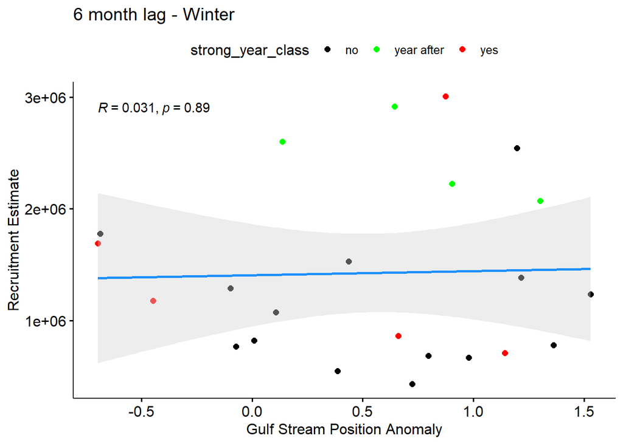

```r
# 6 month lag - Winter
df %>% group_by(year, strong_year_class) %>%
  summarize(gsi = mean(gsi_6),
            r = mean(recruit_est)) %>%
  ggscatter(x = "gsi", y = "r",
            add = "reg.line", conf.int = TRUE,
            color = "strong_year_class", palette = c("black", "green", "red"),
            cor.coef = TRUE, cor.coeff.args = list(method="pearson"),
            add.params=list(color="dodgerblue", fill="lightgray"),
            xlab = "Gulf Stream Position Anomaly", ylab = "Recruitment Estimate",
            title="6 month lag - Winter")
```

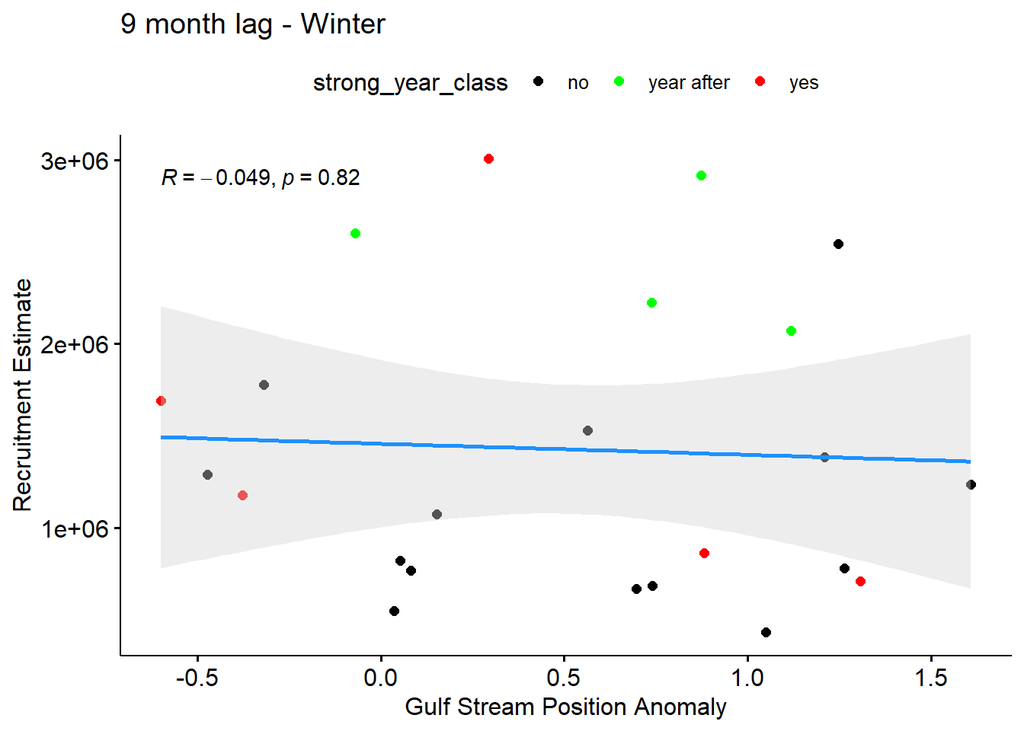

```r
# 9 month lag - Winter
df %>% group_by(year, strong_year_class) %>%
  summarize(gsi = mean(gsi_9),
            r = mean(recruit_est)) %>%
  ggscatter(x = "gsi", y = "r",
            add = "reg.line", conf.int = TRUE,
            color = "strong_year_class", palette = c("black", "green", "red"),
            cor.coef = TRUE, cor.coeff.args = list(method="pearson"),
            add.params=list(color="dodgerblue", fill="lightgray"),
            xlab = "Gulf Stream Position Anomaly", ylab = "Recruitment Estimate",
            title="9 month lag - Winter")
```

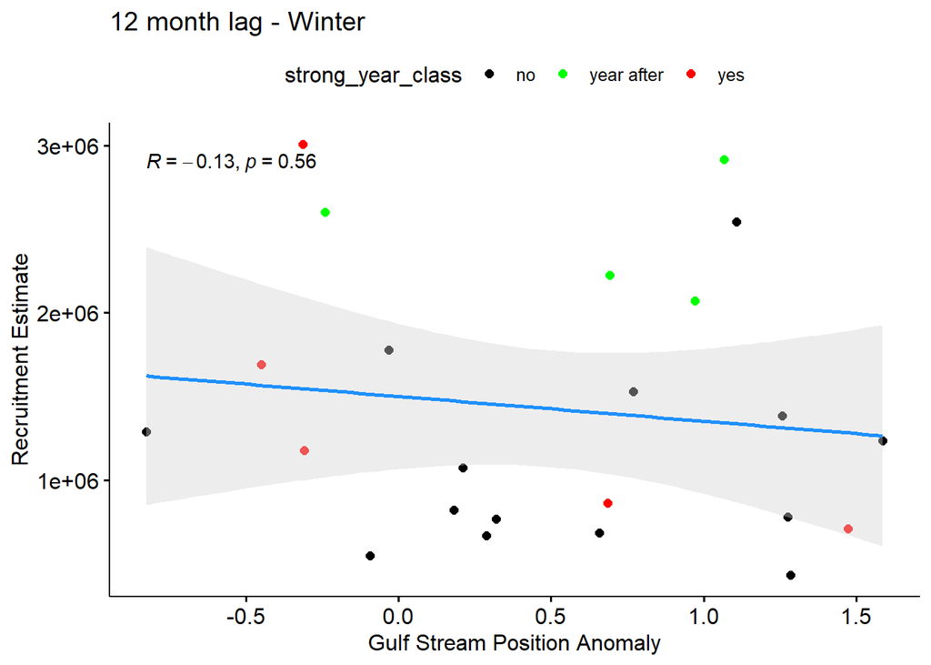

```r
# 12 month lag - Winter
df %>% group_by(year, strong_year_class) %>%
  summarize(gsi = mean(gsi_12),
            r = mean(recruit_est)) %>%
  ggscatter(x = "gsi", y = "r",
            add = "reg.line", conf.int = TRUE,
            color = "strong_year_class", palette = c("black", "green", "red"),
            cor.coef = TRUE, cor.coeff.args = list(method="pearson"),
            add.params=list(color="dodgerblue", fill="lightgray"),
            xlab = "Gulf Stream Position Anomaly", ylab = "Recruitment Estimate",
            title="12 month lag - Winter")
```

#### Food availablity

Larval tilefish eat zooplankton, likely calanus. *Calanus finmarchicus* are a copepod (crustacean) with a one-year life cycle and are an important food source for many commercially important species. Calanus spp. are lipid rich, herbivorous species that eat phytoplankton, diatoms in particular (Hobbs et al. 2020).

Diatoms are often represented as microplankton (>20 µm), but many species are of the nanoplankton size class (2-20 µm), and a smaller few may even overlap with picoplanton size class (<2 µm).

##### Microplankton

```r
micro<-read.csv(here::here('data/phyto_size_class/microplankton_ts_gtf_strata.csv'))

# micro with year lag
micro.lag <- micro %>%
  arrange(year, month) %>%
  mutate(micro_3 = lag(weighted_mean_micro,3),
         micro_6 = lag(weighted_mean_micro,6),
         micro_9 = lag(weighted_mean_micro,9),
         micro_12 = lag(weighted_mean_micro,12))

# Join with recruit estimate
micro.rec <- dplyr::full_join(recruit, micro.lag %>%
                   group_by(year) %>%
                   filter(year %in% c(1998:2020)),
dplyr::select(year, month, mean_cpue, mean_micro, weighted_mean_micro, micro_3, micro_6, micro_9, micro_12),
                 by = join_by(year))
micro.rec <- micro.rec[-c(1:27),] #removes year < 1998 (starting year for analysis)
```

```r
# microplankton
```

##### Microplankton analysis

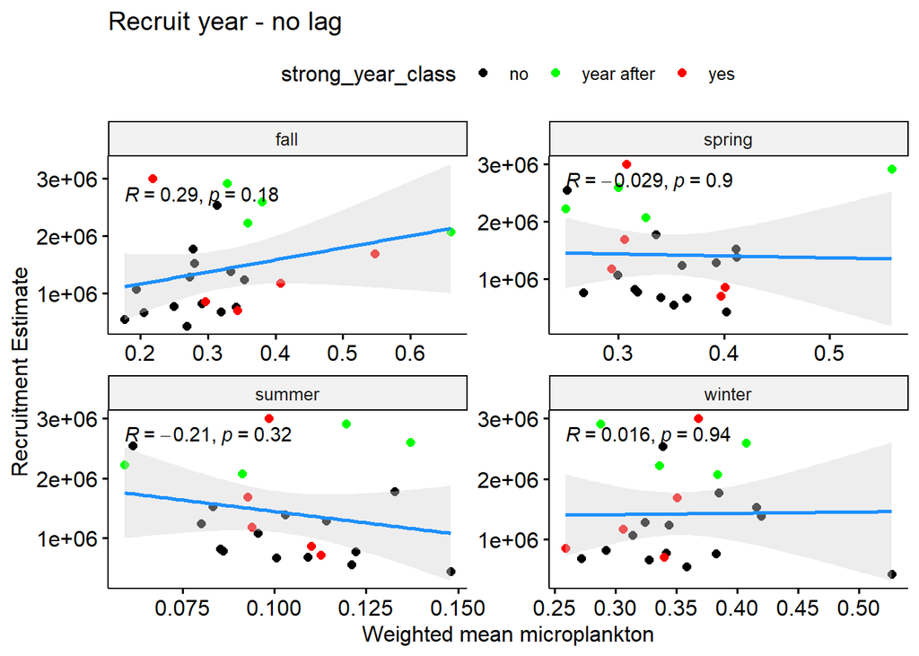

```r
df = micro.rec %>%
  mutate(season = case_when(month %in% c(1,2,3) ~ 'winter',
                            month %in% c(4,5,6) ~ 'spring',
                            month %in% c(7,8,9) ~ 'summer',
                            month %in% c(10,11,12) ~ 'fall'),
         strong_year_class = case_when(year %in% c(1998,1999,2005,2013,2017) ~ 'yes',
                                  year %in% c(2000,2006,2014,2018) ~ 'year after',
                                  year %in% c(2001:2004,2007:2012,2015:2016,2019:2020) ~ 'no'))

# Plot without lag
df %>% group_by(year, season, strong_year_class) %>%
  summarize(micro = mean(weighted_mean_micro),
            r = mean(recruit_est)) %>%
  ggscatter(x = "micro", y = "r",
            add = "reg.line", conf.int = TRUE,
            color = "strong_year_class", palette = c("black", "green", "red"),
            cor.coef = TRUE, cor.coeff.args = list(method="pearson"),
            add.params=list(color="dodgerblue", fill="lightgray"),
            xlab = "Weighted mean microplankton", ylab = "Recruitment Estimate",
            title="Recruit year - no lag")+
  facet_wrap(~season, scales = 'free')
```

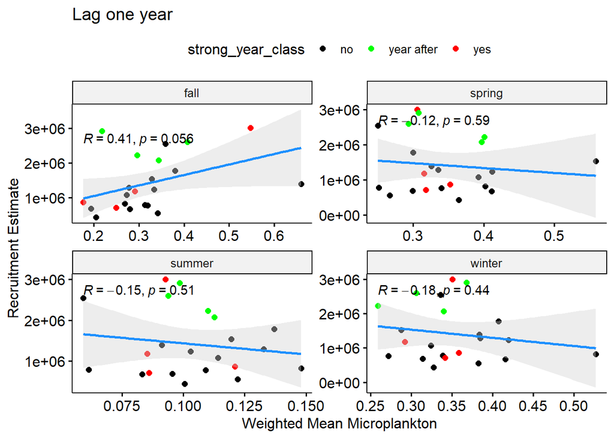

```r
# Plot with lag
df %>% group_by(year, season, strong_year_class) %>%
  summarize(micro = mean(micro_12),
            r = mean(recruit_est)) %>%
  ggscatter(x = "micro", y = "r",
            add = "reg.line", conf.int = TRUE,
            color = "strong_year_class", palette = c("black", "green", "red"),
            cor.coef = TRUE, cor.coeff.args = list(method="pearson"),
            add.params=list(color="dodgerblue", fill="lightgray"),
            xlab = "Weighted Mean Microplankton", ylab = "Recruitment Estimate",
            title="Lag one year")+
  facet_wrap(~season, scales = 'free')
```

Seasonal lags

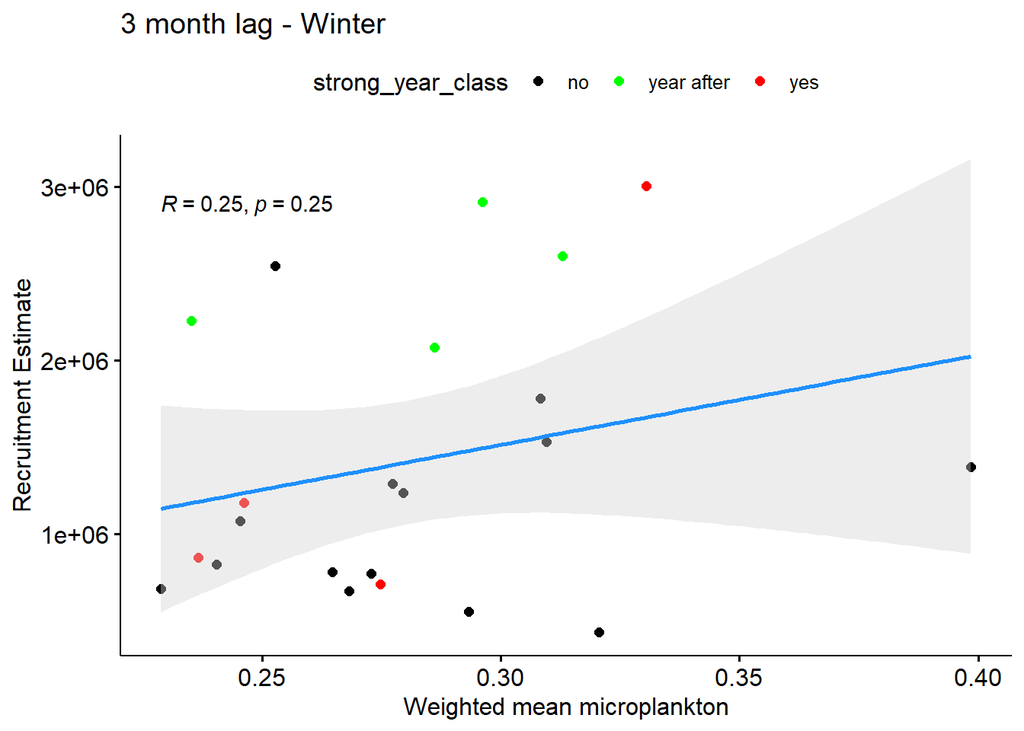

```r
## 3 month lag (winter)

df %>% group_by(year, strong_year_class) %>%
  summarize(micro = mean(micro_3),
            r = mean(recruit_est)) %>%
  ggscatter(x = "micro", y = "r",
            add = "reg.line", conf.int = TRUE,
            color = "strong_year_class", palette = c("black", "green", "red"),
            cor.coef = TRUE, cor.coeff.args = list(method="pearson"),
            add.params=list(color="dodgerblue", fill="lightgray"),
            xlab = "Weighted mean microplankton", ylab = "Recruitment Estimate",
            title="3 month lag - Winter")
```

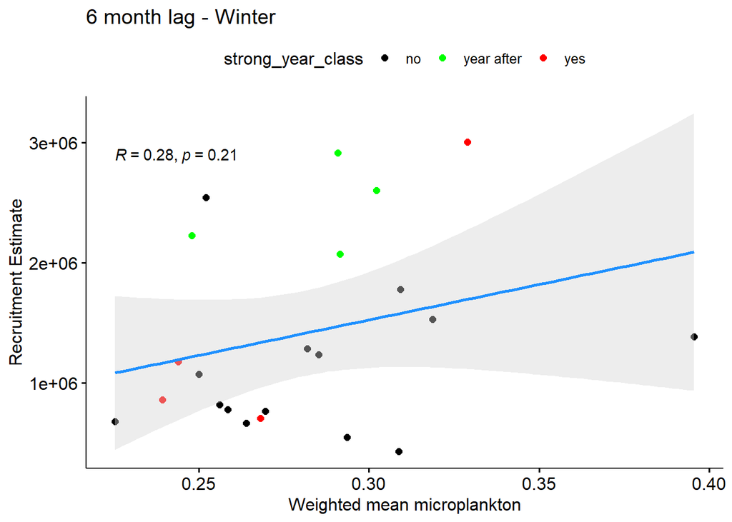

```r
## 6 month lag (winter)

df %>% group_by(year, strong_year_class) %>%
  summarize(micro = mean(micro_6),
            r = mean(recruit_est)) %>%
  ggscatter(x = "micro", y = "r",
            add = "reg.line", conf.int = TRUE,
            color = "strong_year_class", palette = c("black", "green", "red"),
            cor.coef = TRUE, cor.coeff.args = list(method="pearson"),
            add.params=list(color="dodgerblue", fill="lightgray"),
            xlab = "Weighted mean microplankton", ylab = "Recruitment Estimate",
            title="6 month lag - Winter")
```

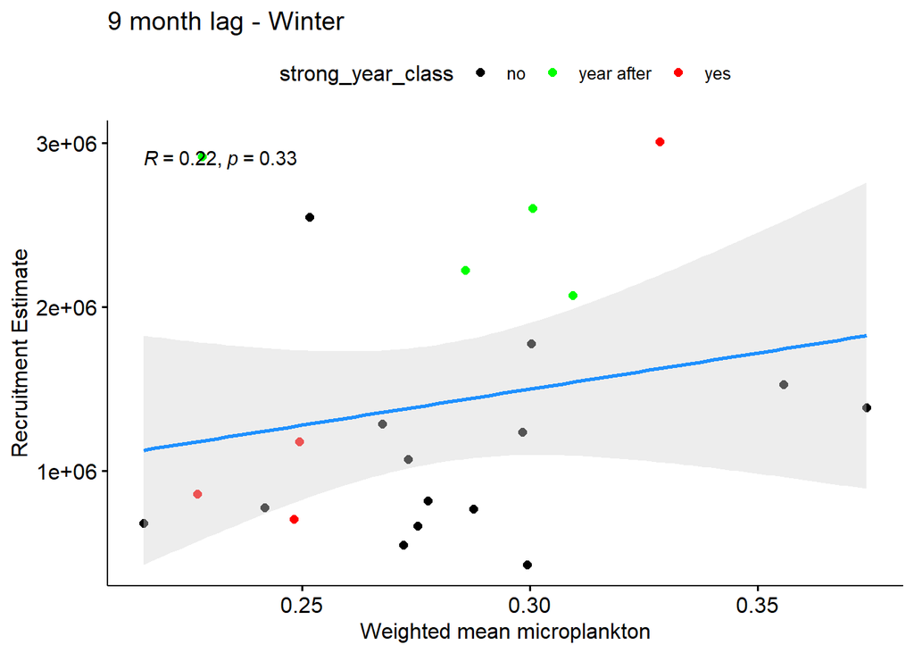

```r
## 9 month lag (winter)

df %>% group_by(year, strong_year_class) %>%
  summarize(micro = mean(micro_9),
            r = mean(recruit_est)) %>%
  ggscatter(x = "micro", y = "r",
            add = "reg.line", conf.int = TRUE,
            color = "strong_year_class", palette = c("black", "green", "red"),
            cor.coef = TRUE, cor.coeff.args = list(method="pearson"),
            add.params=list(color="dodgerblue", fill="lightgray"),
            xlab = "Weighted mean microplankton", ylab = "Recruitment Estimate",
            title="9 month lag - Winter")
```

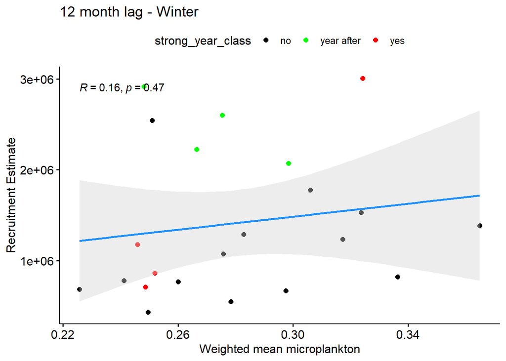

```r
## 12 month lag (winter)

df %>% group_by(year, strong_year_class) %>%
  summarize(micro = mean(micro_12),
            r = mean(recruit_est)) %>%
  ggscatter(x = "micro", y = "r",
            add = "reg.line", conf.int = TRUE,
            color = "strong_year_class", palette = c("black", "green", "red"),
            cor.coef = TRUE, cor.coeff.args = list(method="pearson"),
            add.params=list(color="dodgerblue", fill="lightgray"),
            xlab = "Weighted mean microplankton", ylab = "Recruitment Estimate",
            title="12 month lag - Winter")
```

##### Chlorophyll-A

```r
# CHL-A
chl<-read.csv(here::here('data/chl/chl_ts_gtf_strata.csv'))

# chl with year lag
chl.lag <- chl %>%
  arrange(year, month) %>%
  mutate(chl_3 = lag(weighted_mean_chl,3),
         chl_6 = lag(weighted_mean_chl,6),
         chl_9 = lag(weighted_mean_chl,9),
         chl_12 = lag(weighted_mean_chl,12))

# Join with recruit estimate
chl.rec <- dplyr::full_join(recruit, chl.lag %>%
                   group_by(year) %>%
                   filter(year %in% c(1998:2020)),
dplyr::select(year, month, mean_cpue, mean_chl, weighted_mean_chl, chl_3, chl_6, chl_9, chl_12),
                 by = join_by(year))
chl.rec <- chl.rec[-c(1:27),] #removes year < 1998 (starting year for analysis)
```

```r
# CHL-A
```

##### Chlorophyll-A analysis

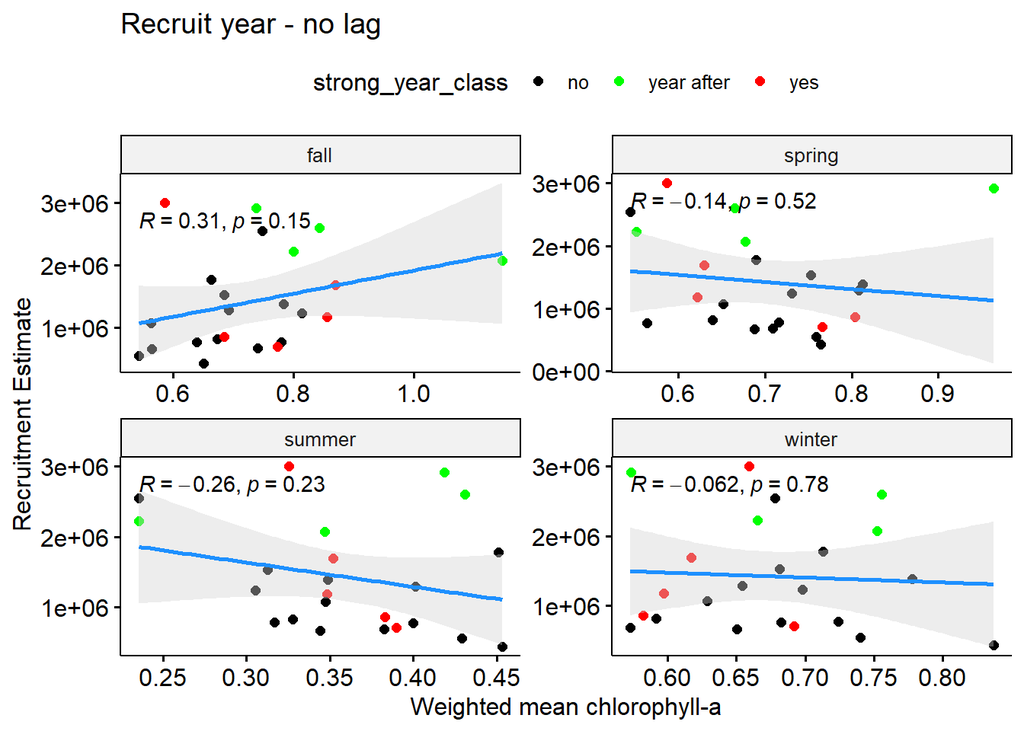

```r
df = chl.rec %>%
  mutate(season = case_when(month %in% c(1,2,3) ~ 'winter',
                            month %in% c(4,5,6) ~ 'spring',
                            month %in% c(7,8,9) ~ 'summer',
                            month %in% c(10,11,12) ~ 'fall'),
         strong_year_class = case_when(year %in% c(1998,1999,2005,2013,2017) ~ 'yes',
                                  year %in% c(2000,2006,2014,2018) ~ 'year after',
                                  year %in% c(2001:2004,2007:2012,2015:2016,2019:2020) ~ 'no'))

# Plot without lag
df %>% group_by(year, season, strong_year_class) %>%
  summarize(chl = mean(weighted_mean_chl),
            r = mean(recruit_est)) %>%
  ggscatter(x = "chl", y = "r",
            add = "reg.line", conf.int = TRUE,
             color = "strong_year_class", palette = c("black", "green", "red"),
            cor.coef = TRUE, cor.coeff.args = list(method="pearson"),
            add.params=list(color="dodgerblue", fill="lightgray"),
            xlab = "Weighted mean chlorophyll-a", ylab = "Recruitment Estimate",
            title="Recruit year - no lag")+
  facet_wrap(~season, scales = 'free')
```

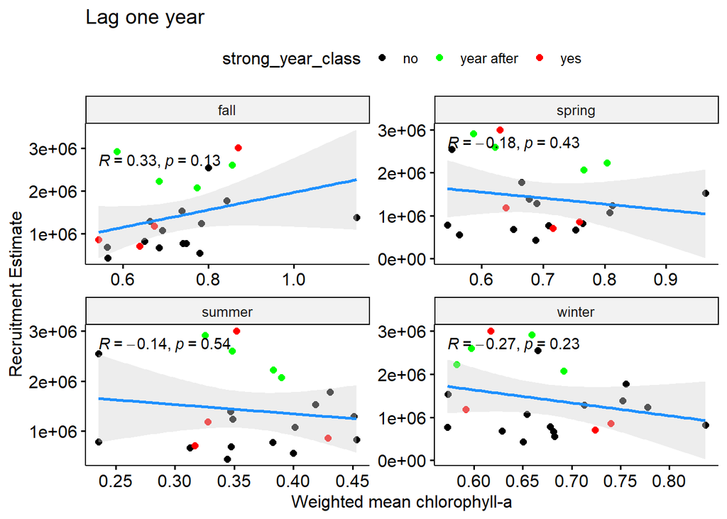

```r
# Plot with lag
df %>% group_by(year, season, strong_year_class) %>%
  summarize(chl = mean(chl_12),
            r = mean(recruit_est)) %>%
  ggscatter(x = "chl", y = "r",
            add = "reg.line", conf.int = TRUE,
             color = "strong_year_class", palette = c("black", "green", "red"),
            cor.coef = TRUE, cor.coeff.args = list(method="pearson"),
            add.params=list(color="dodgerblue", fill="lightgray"),
            xlab = "Weighted mean chlorophyll-a", ylab = "Recruitment Estimate",
            title="Lag one year")+
  facet_wrap(~season, scales = 'free')
```

Seasonal lags

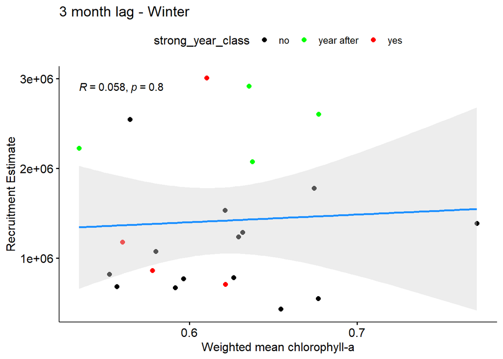

```r
## 3 month lag (winter)

df %>% group_by(year, strong_year_class) %>%
  summarize(chl = mean(chl_3),
            r = mean(recruit_est)) %>%
  ggscatter(x = "chl", y = "r",
            add = "reg.line", conf.int = TRUE,
            color = "strong_year_class", palette = c("black", "green", "red"),
            cor.coef = TRUE, cor.coeff.args = list(method="pearson"),
            add.params=list(color="dodgerblue", fill="lightgray"),
            xlab = "Weighted mean chlorophyll-a", ylab = "Recruitment Estimate",
            title="3 month lag - Winter")
```

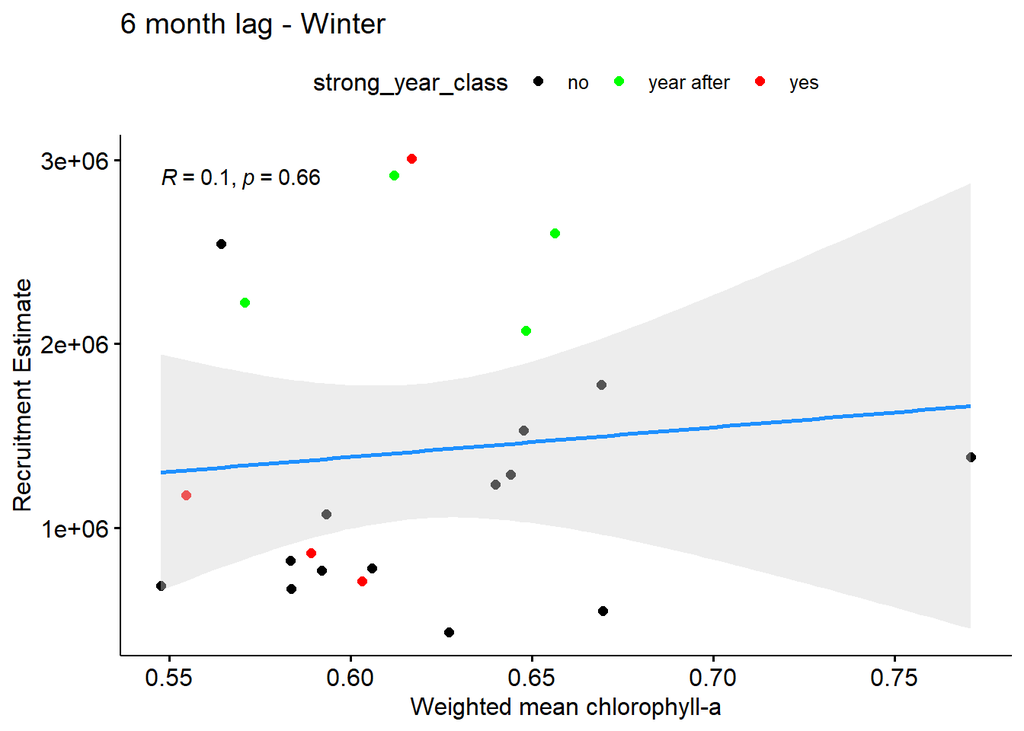

```r
## 6 month lag (winter)

df %>% group_by(year, strong_year_class) %>%
  summarize(chl = mean(chl_6),
            r = mean(recruit_est)) %>%
  ggscatter(x = "chl", y = "r",
            add = "reg.line", conf.int = TRUE,
            color = "strong_year_class", palette = c("black", "green", "red"),
            cor.coef = TRUE, cor.coeff.args = list(method="pearson"),
            add.params=list(color="dodgerblue", fill="lightgray"),
            xlab = "Weighted mean chlorophyll-a", ylab = "Recruitment Estimate",
            title="6 month lag - Winter")
```

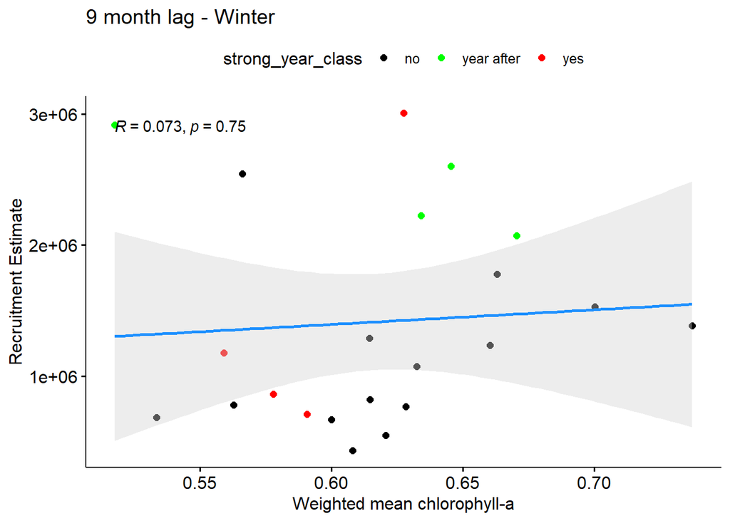

```r
## 9 month lag (winter)

df %>% group_by(year, strong_year_class) %>%
  summarize(chl = mean(chl_9),
            r = mean(recruit_est)) %>%
  ggscatter(x = "chl", y = "r",
            add = "reg.line", conf.int = TRUE,
            color = "strong_year_class", palette = c("black", "green", "red"),
            cor.coef = TRUE, cor.coeff.args = list(method="pearson"),
            add.params=list(color="dodgerblue", fill="lightgray"),
            xlab = "Weighted mean chlorophyll-a", ylab = "Recruitment Estimate",
            title="9 month lag - Winter")
```

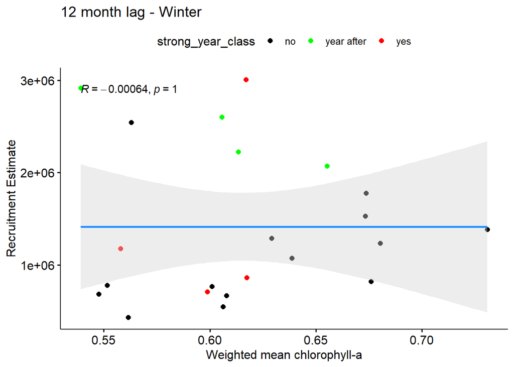

```r
## 12 month lag (winter)

df %>% group_by(year, strong_year_class) %>%
  summarize(chl = mean(chl_12),
            r = mean(recruit_est)) %>%
  ggscatter(x = "chl", y = "r",
            add = "reg.line", conf.int = TRUE,
            color = "strong_year_class", palette = c("black", "green", "red"),
            cor.coef = TRUE, cor.coeff.args = list(method="pearson"),
            add.params=list(color="dodgerblue", fill="lightgray"),
            xlab = "Weighted mean chlorophyll-a", ylab = "Recruitment Estimate",
            title="12 month lag - Winter")
```

##### SST Fronts

```r
# SST fronts
fprob<-read.csv(here::here('data/sst_fronts/fprob_seasonal_ts_gtf_3x3.csv')) #fprob across all individual strata
fprob.ind<-read.csv(here::here('data/sst_fronts/fprob_seasonal_ts_gtf_indv_substrata_3x3.csv')) #mean for each of 14 substrata
fprob.ns<-read.csv(here::here('data/sst_fronts/fprob_seasonal_ts_gtf_n_v_s_substrata_3x3.csv')) #mean for substrata N and S of Hudson canyon

# fprob with year lag
fprob.lag <- fprob %>%
  mutate(fprob_lag1 = lag(weighted_mean_fprob,4))

# Join with recruit estimate
fprob.rec <- dplyr::full_join(recruit, fprob.lag %>%
                   group_by(year) %>%
                   filter(year %in% c(1998:2020)),
dplyr::select(year, season, recruit_est, mean_fprob, weighted_mean_fprob, fprob_lag1),
                 by = join_by(year))
fprob.rec <- fprob.rec[-c(1:29),] #removes year < 2000 (starting year for fprob)
```

##### SST Fronts analysis

**Fprob of each substrata**

```r
#join data
ind.rec <- dplyr::full_join(recruit, fprob.ind %>%
                   group_by(year) %>%
                   filter(year %in% c(1998:2020)),
dplyr::select(year, season, recruit_est, mean_fprob, weighted_mean_fprob, fprob_lag1),
                 by = join_by(year))
ind.rec <- ind.rec[-c(1:29),]  #begin at year 2000
```

**Fprob N/S of Hudson Canyon**

```r
#join data
ns.rec <- dplyr::full_join(recruit, fprob.ns %>%
                   group_by(year) %>%
                   filter(year %in% c(1998:2020)),
dplyr::select(year, season, recruit_est, mean_fprob, weighted_mean_fprob, fprob_lag1),
                 by = join_by(year))
ns.rec <- ns.rec[-c(1:29),]  #begin at year 2000
```

##### GAMs

```r
## habitat (sst/bt/sal?)
habitat <- dplyr::full_join(
  sst.rec, bt.rec, by = join_by(year, month, recruit_est)) %>%
  dplyr::select(year, month, recruit_est, weighted_mean_sst, weighted_mean_bt)


habitat.gam <- gam(recruit_est ~ s(weighted_mean_sst, k=10) + s(weighted_mean_bt, k=10), data=habitat, method="REML")
summary(habitat.gam)
```

```
##
## Family: gaussian
## Link function: identity
##
## Formula:
## recruit_est ~ s(weighted_mean_sst, k = 10) + s(weighted_mean_bt,
##     k = 10)
##
## Parametric coefficients:
##             Estimate Std. Error t value Pr(>|t|)
## (Intercept)  1331947      45743   29.12   <2e-16 ***
## ---
## Signif. codes:  0 '***' 0.001 '**' 0.01 '*' 0.05 '.' 0.1 ' ' 1
##
## Approximate significance of smooth terms:
##                        edf Ref.df     F p-value
## s(weighted_mean_sst) 1.002  1.003 0.082   0.777
## s(weighted_mean_bt)  1.003  1.006 0.000   1.000
##
## R-sq.(adj) =  -0.00768   Deviance explained = 0.0401%
## -REML = 3706.5  Scale est. = 5.252e+11  n = 251
```

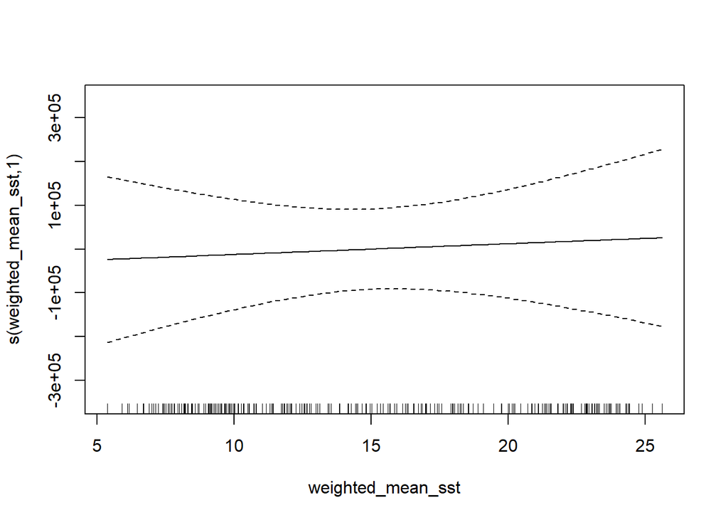

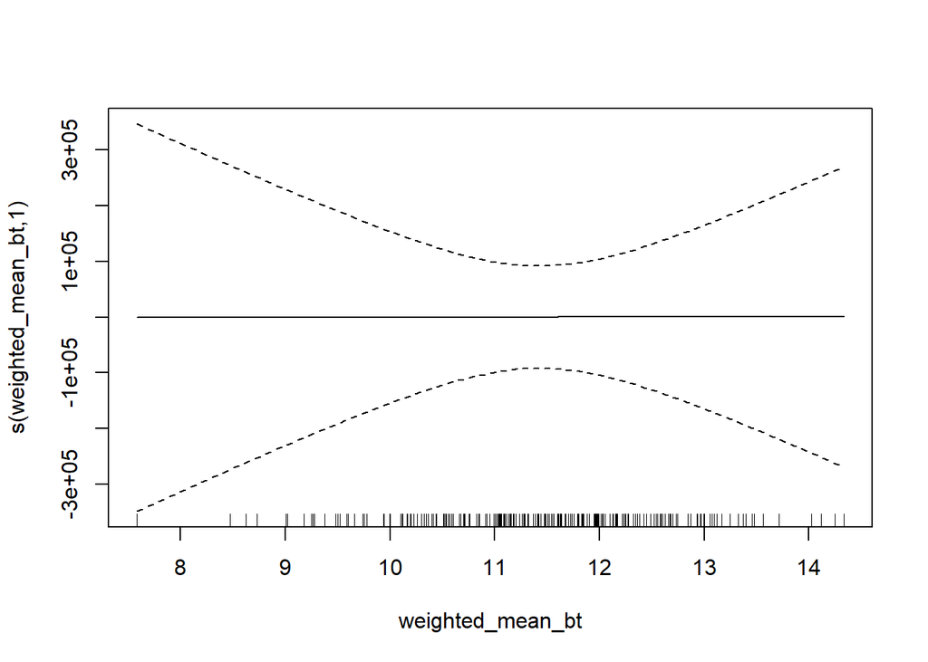

```r
plot(habitat.gam, seWithMean=TRUE)
```

```r
##currents (shelfvol/gsi)
currents <- dplyr::full_join(
  df.join.shlf, df.gsi, by = join_by(year, month, recruit_est)) %>%
  dplyr::select(year,month, recruit_est, mean_v, GSI)
#no gsi <1998, no shlfvol 2020 >

currents.gam <- gam(recruit_est ~ s(mean_v, k=10) + s(GSI, k=10), data=currents, method="REML")
summary(currents.gam)
```

```
##
## Family: gaussian
## Link function: identity
##
## Formula:
## recruit_est ~ s(mean_v, k = 10) + s(GSI, k = 10)
##
## Parametric coefficients:
##             Estimate Std. Error t value Pr(>|t|)
## (Intercept)  1425673      72833   19.57   <2e-16 ***
## ---
## Signif. codes:  0 '***' 0.001 '**' 0.01 '*' 0.05 '.' 0.1 ' ' 1
##
## Approximate significance of smooth terms:
##             edf Ref.df     F p-value
## s(mean_v) 2.234  2.812 1.680   0.255
## s(GSI)    1.002  1.004 0.417   0.520
##
## R-sq.(adj) =  0.0305   Deviance explained =  5.9%
## -REML = 1624.6  Scale est. = 5.8882e+11  n = 111
```

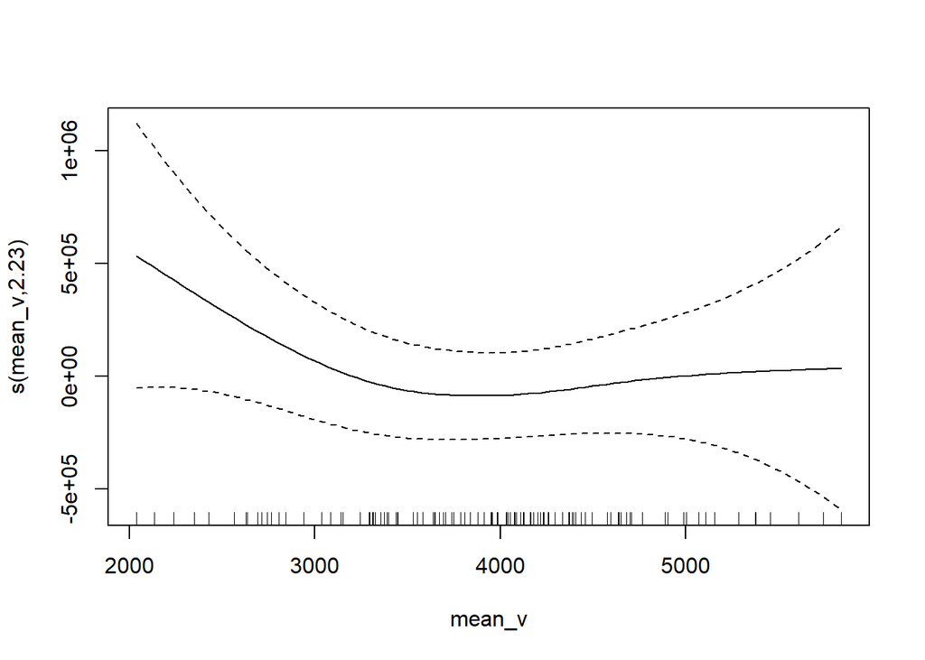

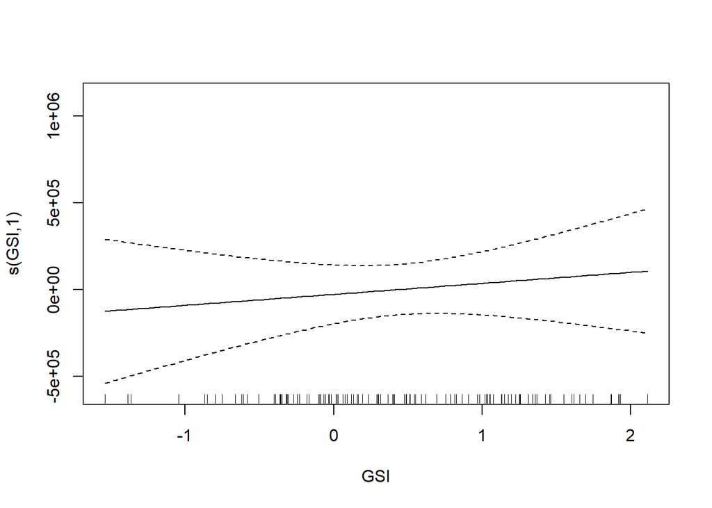

```r
plot(currents.gam, seWithMean=TRUE)
```

```r
## food availability (micro/chl-a/sstfronts)
food1<- dplyr::full_join(
  micro.rec, chl.rec, by = join_by(year, month, recruit_est)) %>%
  dplyr::select(year,month, recruit_est, weighted_mean_micro, weighted_mean_chl)

food<-read.csv(here::here('data/food_rec.csv')) #join with fprob and grouped by season

food.gam <- gam(recruit_est ~ s(weighted_mean_micro, k=10) + s(weighted_mean_chl, k=10) + s(weighted_mean_fprob, k=10), data=food, method="REML")
summary(food.gam)
```

```
##
## Family: gaussian
## Link function: identity
##
## Formula:
## recruit_est ~ s(weighted_mean_micro, k = 10) + s(weighted_mean_chl,
##     k = 10) + s(weighted_mean_fprob, k = 10)
##
## Parametric coefficients:
##             Estimate Std. Error t value Pr(>|t|)
## (Intercept)  1338230      44632   29.98   <2e-16 ***
## ---
## Signif. codes:  0 '***' 0.001 '**' 0.01 '*' 0.05 '.' 0.1 ' ' 1
##
## Approximate significance of smooth terms:
##                          edf Ref.df     F p-value
## s(weighted_mean_micro) 1.001  1.002 0.281  0.5969
## s(weighted_mean_chl)   1.003  1.006 0.057  0.8159
## s(weighted_mean_fprob) 5.188  6.311 2.527  0.0332 *
## ---
## Signif. codes:  0 '***' 0.001 '**' 0.01 '*' 0.05 '.' 0.1 ' ' 1
##
## R-sq.(adj) =  0.0512   Deviance explained = 7.84%
## -REML = 3707.8  Scale est. = 5.0199e+11  n = 252
```

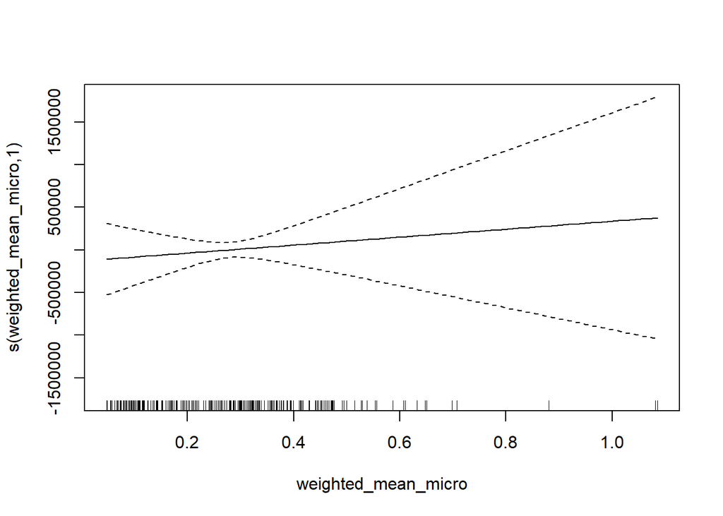

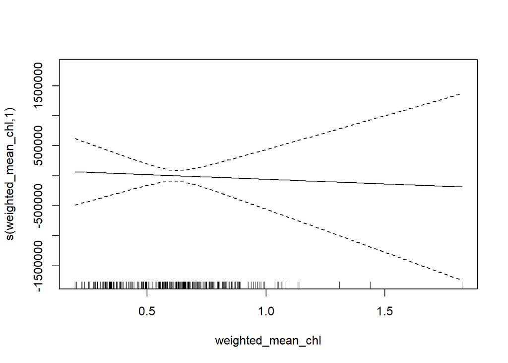

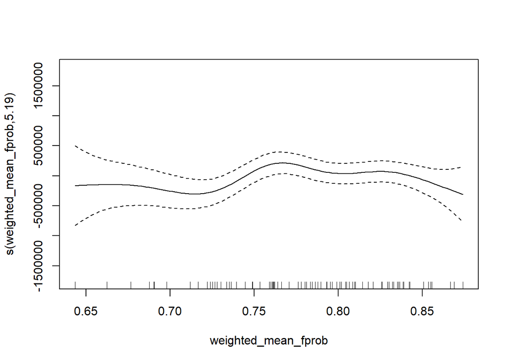

```r
plot(food.gam, seWithMean=TRUE)
```

References:

Joyce, Terrence M, Young-Oh Kwon, Hyodae Seo, and Caroline C Ummenhofer. 2019. “Meridional Gulf Stream Shifts Can Influence Wintertime Variability in the North Atlantic Storm Track and Greenland Blocking.” Geophysical Research Letters 46 (3): 1702–8. https://doi.org/10.1029/2018GL081087.

Hobbs, L., Banas, N. S., Cottier, F. R., Berge, J., & Daase, M. (2020). Eat or sleep: availability of winter prey explains mid-winter and spring activity in an Arctic Calanus population. Frontiers in Marine Science, 7, 541564.

Pérez-Hernández, M. Dolores, and Terrence M. Joyce. 2014. “Two Modes of Gulf Stream Variability Revealed in the Last Two Decades of Satellite Altimeter Data.” Journal of Physical Oceanography 44 (1): 149–63. https://doi.org/10.1175/JPO-D-13-0136.1.